# Summary statistics of simulated variants, derived variants, and extractred ancestral sequences

2024-11-07

# Variant simulator; report

### Node used for reconstructing ancestral genome sequence

If a (newick) phylogenetic tree file has been provided, the visualisation of the MSA used in the calculations is shown below. The two chosen groups (i.e. ‘ingroup’ / species of interest, and outgroup) are highlighted in the tree. The outgroup, used in the computation or not, is the outgroup, which together with the reference species of interest coalesce at the node of interest, from which the ancestral sequence have been extracted. Most recent common ancestor (MRCA) is highlighted in purple and labeled. The rest of the clades in the alignment are shown in lighter grey. Regardless whether a reconstructed ancestral sequence at a node, or an outgroup, has been chosen as the ancestor, the MRCA will be highlighted.

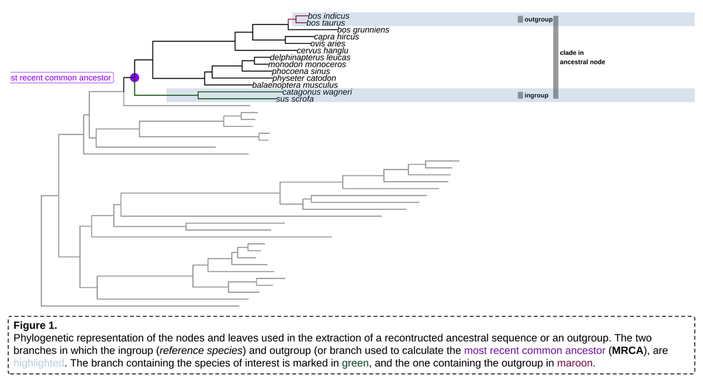

### Distribution of simulated variants across the reference genome

If an ideogram (often possible to download on the UCSC website, [here](https://genome.ucsc.edu/cgi-bin/hgTables)) has been provided, the distribution of simulated variants is shown across the genome of the species of interest. The grey distribution corresponds to the total amount of simulated variants, whereas the red distribution corresponds to the subset that is overlapping with a corresponding non-gap ancestral sequence. If there is no forced sub-sampling due to lack of ancestral sequence, the distribution will be fully red.

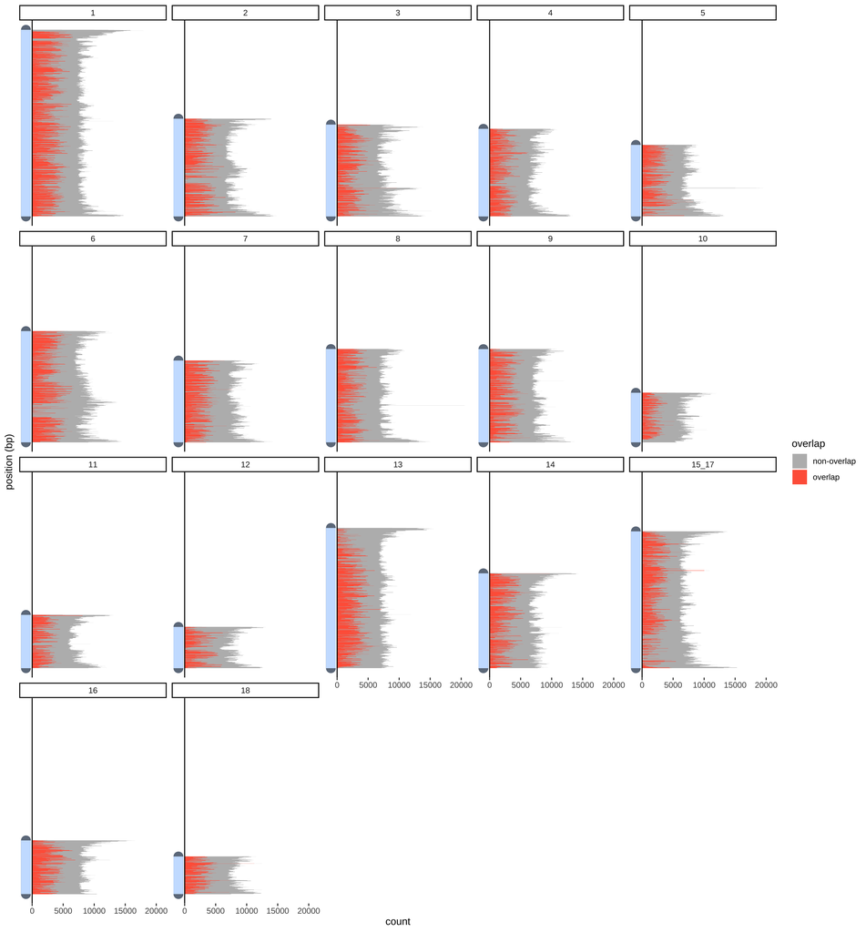

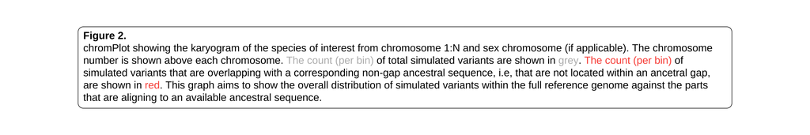

### Distribution of derived variants across the reference genome

If an ideogram (often possible to download on the UCSC website, [here](https://genome.ucsc.edu/cgi-bin/hgTables)) has been provided, the distribution of derived variants is shown across the genome of the species of interest. The distribution of derived variants across the genome is shown in red.

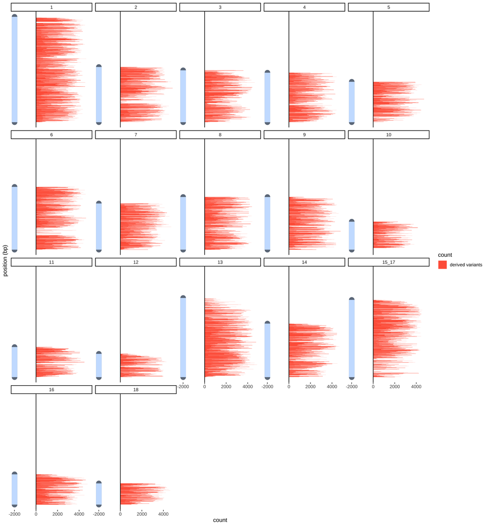

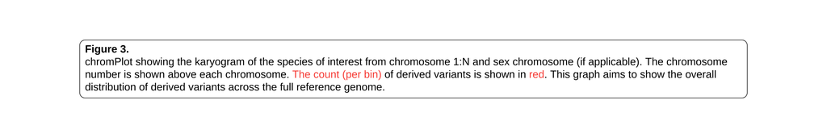

### How much of the reference genome that has an available, aligned reconstructed ancestral sequence

**Table 1** Fraction of refence genome that has an available aligned reconstructed ancestral sequence. The leftmost column represents the total size of the source chromosome (in base pairs), from the species of interest. The middle column represents the size (in base pairs) of the recontructed ancestral genome (or size of aligned outgroup without gaps). The rightmost column represents the fraction of the reference genome that is covered by an ancestral sequence, i.e. the fraction of the reference with a corresponding non-gap ancestral alignment.

|  | Size of ref. genome | Size of reconstructed genome | Fraction covered of ref. genome |
| --- | --- | --- | --- |
| 1 | 277 851 379 | 66 396 801 | 0.24 |
| 2 | 145 549 147 | 30 578 806 | 0.21 |
| 3 | 136 770 423 | 27 769 000 | 0.20 |
| 4 | 130 488 646 | 25 506 433 | 0.20 |
| 5 | 106 564 835 | 21 382 231 | 0.20 |
| 6 | 165 568 887 | 36 200 919 | 0.22 |
| 7 | 121 779 005 | 27 074 055 | 0.22 |
| 8 | 138 913 488 | 28 493 809 | 0.21 |
| 9 | 138 776 831 | 29 208 182 | 0.21 |
| 10 | 73 781 108 | 11 630 205 | 0.16 |
| 11 | 79 373 231 | 14 273 688 | 0.18 |
| 12 | 61 428 131 | 11 726 337 | 0.19 |
| 13 | 208 716 492 | 45 957 035 | 0.22 |
| 14 | 141 217 515 | 29 015 747 | 0.21 |
| 15_17 | 203 673 900 | 39 117 516 | 0.19 |
| 16 | 79 833 563 | 18 793 500 | 0.24 |
| 18 | 55 909 202 | 11 921 214 | 0.21 |

### Number of simulated variants

##### and how many are overlapping with an available ancestral sequence

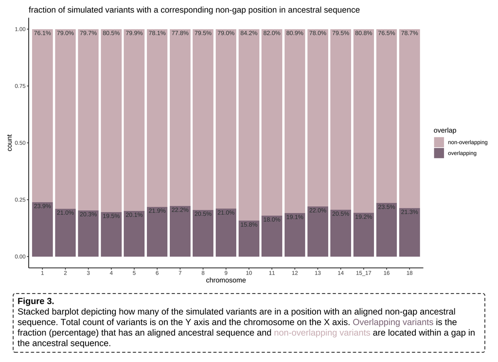

##### Table with corresponding data:

**Table 2**. Fraction of simulated SNPs that is overlapping with a reconstructed ancestral sequence. Column explanation from left to right: **i)** chromosome number **ii)** the total number of simulated SNPs **iii)** the *number* of simulated SNPs that are overlapping with a non-gap align recontructed ancestral sequence. **iv)** the *fraction* of simulated SNPs that are overlapping with a non-gap align recontructed ancestral sequence. **v)** the total number of derived variants.

|  | No of sim. SNPs | Number of sim. SNPs overlapping ancestral seq. | Fraction of sim. SNPs overlapping ancestral seq. | Number of derived variants |
| --- | --- | --- | --- | --- |
| 1 | 22 927 644 | 5 280 279 | 0.23 | 4 209 724 |
| 2 | 11 521 337 | 2 351 831 | 0.20 | 1 987 404 |
| 3 | 11 017 857 | 2 140 660 | 0.19 | 1 796 664 |
| 4 | 9 690 582 | 1 798 554 | 0.19 | 1 635 245 |
| 5 | 8 140 487 | 1 525 271 | 0.19 | 1 363 294 |
| 6 | 14 155 433 | 2 959 072 | 0.21 | 2 358 690 |
| 7 | 10 126 906 | 2 132 350 | 0.21 | 1 733 737 |
| 8 | 10 765 518 | 2 120 466 | 0.20 | 1 888 182 |
| 9 | 11 010 436 | 2 220 127 | 0.20 | 1 919 192 |
| 10 | 5 181 040 | 767 340 | 0.15 | 789 214 |
| 11 | 5 783 835 | 979 858 | 0.17 | 940 246 |
| 12 | 4 941 773 | 913 334 | 0.18 | 745 254 |
| 13 | 15 935 441 | 3 329 464 | 0.21 | 2 916 604 |
| 14 | 10 703 794 | 2 123 606 | 0.20 | 1 830 163 |
| 15_17 | 14 615 013 | 2 605 186 | 0.18 | 2 472 730 |
| 16 | 6 884 197 | 1 549 499 | 0.23 | 1 240 541 |
| 18 | 4 706 393 | 953 691 | 0.20 | 783 897 |

### Types of simulated mutations

[figure not shown]

##### Table with corresponding data:

**Table 3** Fraction of mutation types across the simulated variants with an available corresponding ancestral sequence. Column explanation, starting from left: **i)** chromosome number **ii)** the total number of SNPs **iii)** the fraction of transitions **iv)** the fraction of transversions **v)** the fraction of CpG site mutations **vi)** the fraction of non-CpG mutations (transitions + transversions)

|  | No. of SNPs | Fraction transitions | Fraction transversions | Fraction CpGs | Fraction non-CpGs (1-CpGs) |
| --- | --- | --- | --- | --- | --- |
| 1 | 5 280 279 | 0.51 | 0.31 | 0.18 | 0.82 |
| 2 | 2 351 831 | 0.47 | 0.29 | 0.24 | 0.76 |
| 3 | 2 140 660 | 0.45 | 0.27 | 0.27 | 0.73 |
| 4 | 1 798 554 | 0.48 | 0.30 | 0.22 | 0.78 |
| 5 | 1 525 271 | 0.48 | 0.30 | 0.22 | 0.78 |
| 6 | 2 959 072 | 0.46 | 0.28 | 0.26 | 0.74 |
| 7 | 2 132 350 | 0.48 | 0.29 | 0.22 | 0.78 |
| 8 | 2 120 466 | 0.50 | 0.31 | 0.19 | 0.81 |
| 9 | 2 220 127 | 0.49 | 0.30 | 0.21 | 0.79 |
| 10 | 767 340 | 0.45 | 0.27 | 0.28 | 0.72 |
| 11 | 979 858 | 0.47 | 0.29 | 0.24 | 0.76 |
| 12 | 913 334 | 0.40 | 0.24 | 0.36 | 0.64 |
| 13 | 3 329 464 | 0.52 | 0.32 | 0.17 | 0.83 |
| 14 | 2 123 606 | 0.47 | 0.28 | 0.25 | 0.75 |
| 15_17 | 2 605 186 | 0.49 | 0.30 | 0.21 | 0.79 |
| 16 | 1 549 499 | 0.51 | 0.32 | 0.17 | 0.83 |
| 18 | 953 691 | 0.47 | 0.29 | 0.24 | 0.76 |

### Types of derived mutations*

- CpG mutation information is not available.

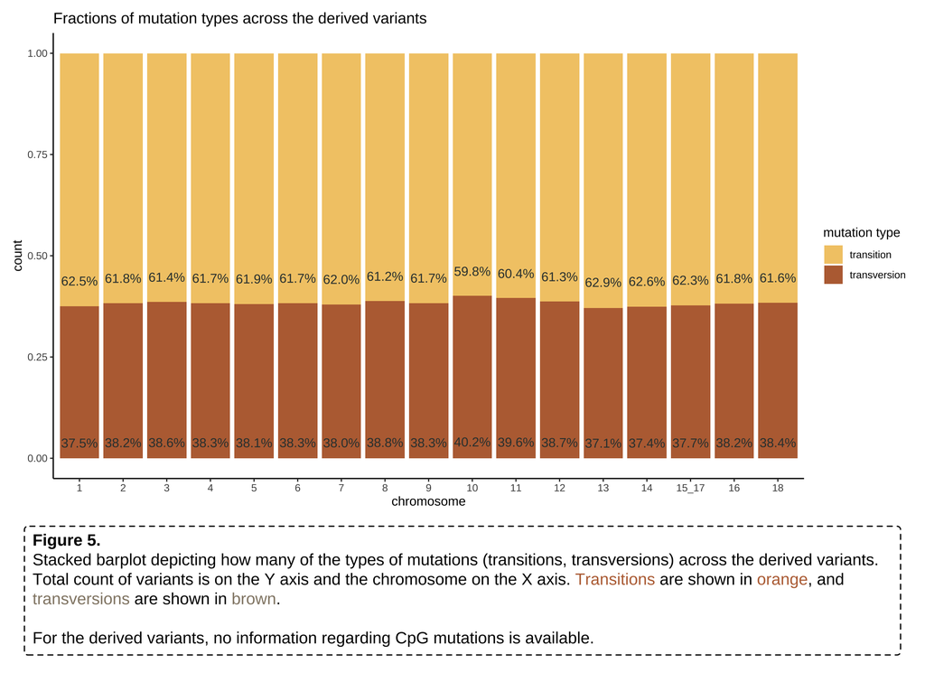

##### Table with corresponding data:

**Table 4** Fraction of mutation types across the derived variants. Column explanation, starting from left: **i)** chromosome number **ii)** the total number of SNPs **iii)** the fraction of transitions **iv)** the fraction of transversions.

|  | No. of SNPs | Fraction transitions | Fraction transversions |
| --- | --- | --- | --- |
| 1 | 4 209 724 | 0.62 | 0.38 |
| 2 | 1 987 404 | 0.62 | 0.38 |
| 3 | 1 796 664 | 0.61 | 0.39 |
| 4 | 1 635 245 | 0.62 | 0.38 |
| 5 | 1 363 294 | 0.62 | 0.38 |
| 6 | 2 358 690 | 0.62 | 0.38 |
| 7 | 1 733 737 | 0.62 | 0.38 |
| 8 | 1 888 182 | 0.61 | 0.39 |
| 9 | 1 919 192 | 0.62 | 0.38 |
| 10 | 789 214 | 0.60 | 0.40 |
| 11 | 940 246 | 0.60 | 0.40 |
| 12 | 745 254 | 0.61 | 0.39 |
| 13 | 2 916 604 | 0.63 | 0.37 |
| 14 | 1 830 163 | 0.63 | 0.37 |
| 15_17 | 2 472 730 | 0.62 | 0.38 |
| 16 | 1 240 541 | 0.62 | 0.38 |
| 18 | 783 897 | 0.62 | 0.38 |

### Visualisation of gene density

#### and CDS overlap

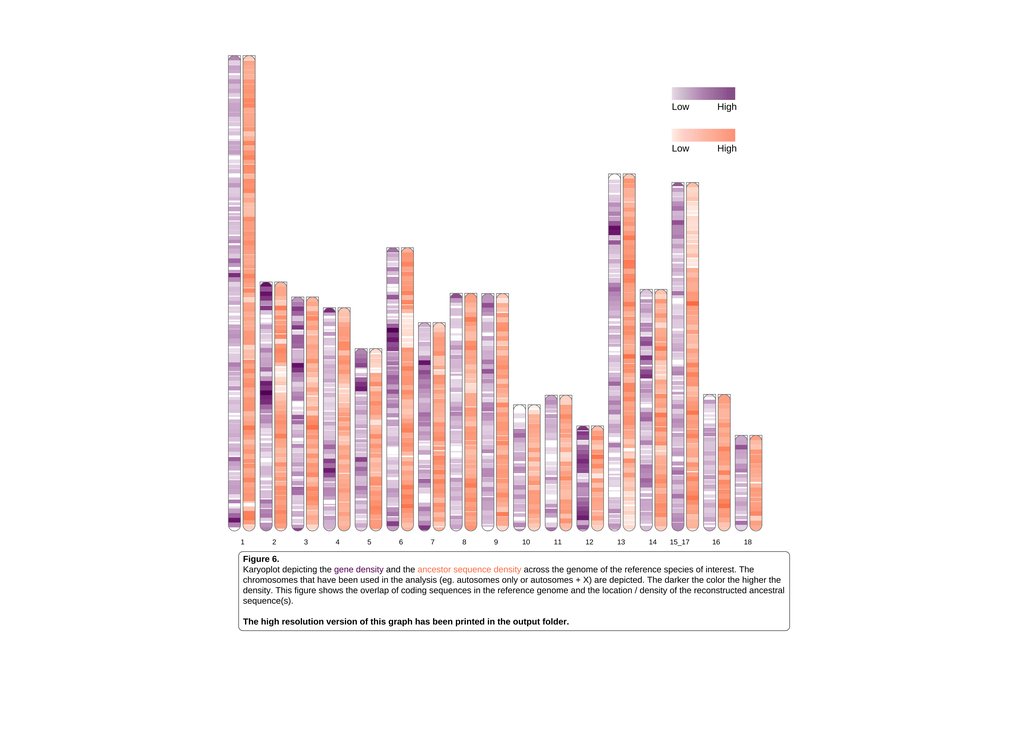

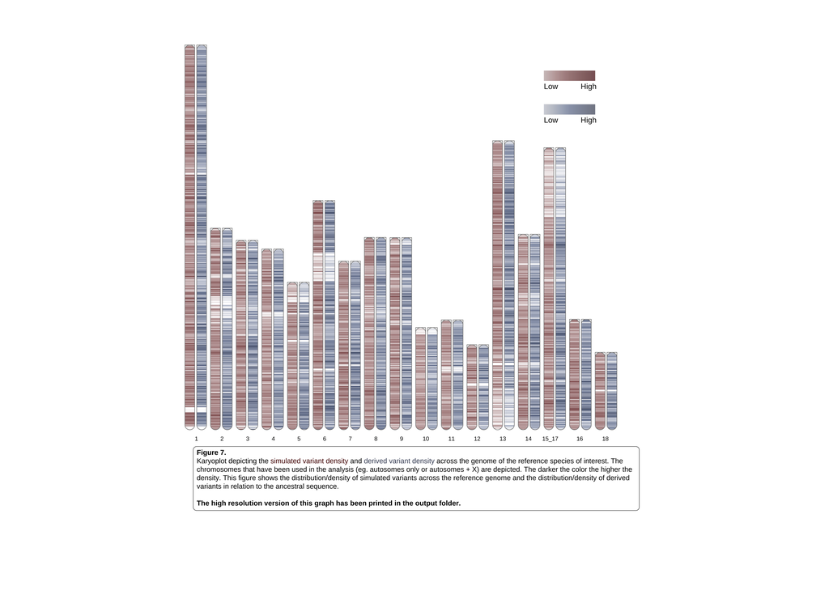

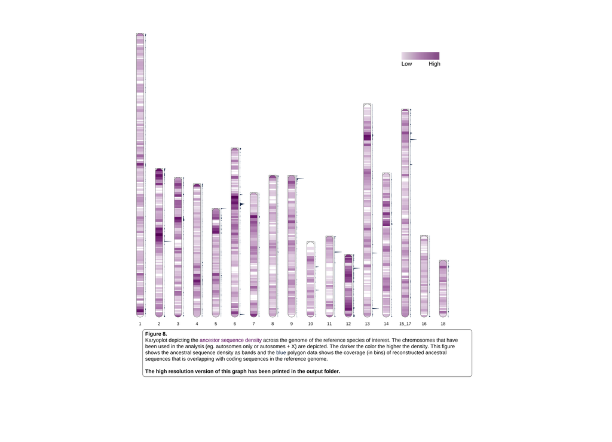

### Validation of simulation parameters

Number of mutations, fractions, and substitution rates. To make sure the simulation was performed as expected, the leftmost part is the calculated numbers and rates in the parameter files, including the total number of simulated variants per chromosome, based on information from the ancestor and reference species. The middle part is the (re)calculated numbers and rates based on the total number of simulated variants. The rightmost part is the (re)calculated numbers and rates within the subset with a corresponding non-gap ancestral sequence. The comparison of parameters and simulated variants is to make sure that the simulation has been perform as intended, and the comparison between total set and the subset is to make sure that the distribution is the same even if the variants are forced to be down-sampled due to the lack of an available ancestral sequence.

Comparison of numebr of mutations between log files and actual simulated files

| Parameter files | Parameter files | Parameter files | Simulated variant file | Simulated variant file | Simulated variant file | Simulated variant file (filtered for positions with a corresponding non-gap ancestral position) | Simulated variant file (filtered for positions with a corresponding non-gap ancestral position) | Simulated variant file (filtered for positions with a corresponding non-gap ancestral position) |
| --- | --- | --- | --- | --- | --- | --- | --- | --- |
| Chromosome considered: 1 |  |  | Chromosome considered: 1 |  |  | Chromosome considered: 1 |  |  |
| Total mut: 4827345 |  |  | Total mut: 18161574 |  |  | Total mut: 4356214 |  |  |
| #AC | AG | AT | #AC | AG | AT | #AC | AG | AT |
| 336961 | 823109 | 272737 | 1374900 | 3167269 | 977064 | 334445 | 768760 | 236989 |
| 6.98% | 17.05% | 5.65% | 7.57% | 17.44% | 5.38% | 7.68% | 17.65% | 5.44% |
| #CA | CG | CT | #CA | CG | CT | #CA | CG | CT |
| 157024 | 138714 | 685399 | 551178 | 546249 | 2459393 | 130048 | 129229 | 579072 |
| 3.25% | 2.87% | 14.20% | 3.03% | 3.01% | 13.54% | 2.99% | 2.97% | 13.29% |
| #GA | GC | GT | #GA | GC | GT | #GA | GC | GT |
| 687517 | 139186 | 158171 | 2459521 | 547243 | 550892 | 580295 | 128684 | 130379 |
| 14.24% | 2.88% | 3.28% | 13.54% | 3.01% | 3.03% | 13.32% | 2.95% | 2.99% |
| #TA | TC | TG | #TA | TC | TG | #TA | TC | TG |
| 272024 | 820044 | 336459 | 977767 | 3169874 | 1380224 | 236775 | 767214 | 334324 |
| 5.64% | 16.99% | 6.97% | 5.38% | 17.45% | 7.60% | 5.44% | 17.61% | 7.67% |
| Total CpG mut: 651630 |  |  | Total CpG mut: 4766070 |  |  | Total CpG mut: 924065 |  |  |
| #CA | CG | CT (CpG) | #CA | CG | CT (CpG) | #CA | CG | CT (CpG) |
| 56926 | 46325 | 221615 | 403599 | 369709 | 1609977 | 78036 | 71493 | 312889 |
| 8.74% | 7.11% | 34.01% | 8.47% | 7.76% | 33.78% | 8.44% | 7.74% | 33.86% |
| #GA | GC | GT (CpG) | #GA | GC | GT (CpG) | #GA | GC | GT (CpG) |
| 222914 | 46453 | 57397 | 1607169 | 371185 | 404431 | 311614 | 71744 | 78289 |
| 34.21% | 7.13% | 8.81% | 33.72% | 7.79% | 8.49% | 33.72% | 7.76% | 8.47% |
| Chromosome considered: 2 |  |  | Chromosome considered: 2 |  |  | Chromosome considered: 2 |  |  |
| Total mut: 2264703 |  |  | Total mut: 26630670 |  |  | Total mut: 6142157 |  |  |
| #AC | AG | AT | #AC | AG | AT | #AC | AG | AT |
| 172849 | 391957 | 121834 | 1995289 | 4598634 | 1417532 | 466741 | 1072736 | 330938 |
| 7.63% | 17.31% | 5.38% | 7.49% | 17.27% | 5.32% | 7.60% | 17.47% | 5.39% |
| #CA | CG | CT | #CA | CG | CT | #CA | CG | CT |
| 67919 | 71674 | 306816 | 819329 | 813096 | 3659674 | 186264 | 184876 | 829324 |
| 3.00% | 3.16% | 13.55% | 3.08% | 3.05% | 13.74% | 3.03% | 3.01% | 13.50% |
| #GA | GC | GT | #GA | GC | GT | #GA | GC | GT |

[output cut: 327 more lines]